# TFM

Byron Enriquez, Paulo Gonzalez, Julio Martínez

2023-11-07

## CRISP-DM: Cross-Industry Standard Process for Data Mining

1. **Comprensión del negocio:** Define los objetivos del proyecto.
2. **Comprensión de los datos:** Recopila y explora los datos relevantes.
3. **Preparación de datos:** Limpia y transforma los datos.
4. **Modelado:** Aplica técnicas de modelado de datos.
5. **Evaluación:** Evalúa los modelos construidos.
6. **Despliegue:** Implementa la solución en producción.
7. **Documentación:** Documenta el proceso y mejora continuamente.

El CRISP-DM es flexible y se adapta a proyectos de minería de datos, guiando los objetivos de negocio.

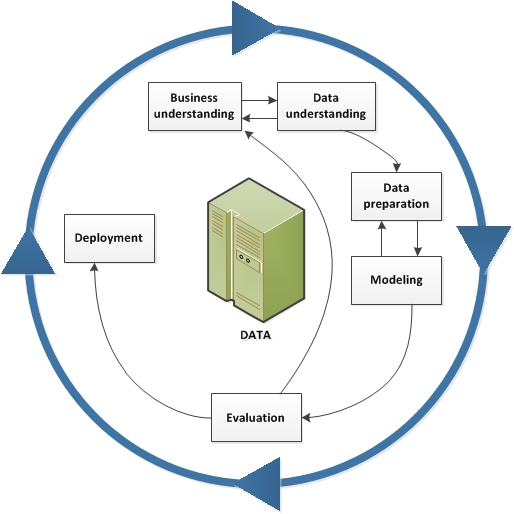

## 1. Comprensión del negocio

### 1.1 Descripción del negocio

Pan Pita David’s es una empresa que se especializa en la producción y distribución de productos orgánicos, con un enfoque en harinas de excelente calidad, libres de grasas trans y ricos en proteínas y fibra. Sus principales productos incluyen:

- **Tahini**: Una deliciosa pasta a base de ajonjolí tostado, que aporta un sabor único a diversas recetas. Es conocido por ser beneficioso para la salud cardíaca debido a su contenido de grasas insaturadas y ácidos grasos, además de ser una fuente rica en fibra y vitaminas B6 y B12.
- **Pan Pita**: Ofrecen pan pita orgánico, bajo en grasas trans y rico en proteínas y fibra. Este producto versátil se presenta en versiones blancas e integrales, y es ideal para la preparación de wraps, burritos, sharwamas, gyros, pizzas, entre otros.
- **Mini Pan Pita**: Similar al pan pita, pero en un formato más pequeño. También es orgánico, bajo en grasas trans y una fuente de proteínas y fibra. Perfecto para usar en una variedad de platos y bocadillos.
- **Pita Chips**: Chips horneados elaborados a partir de pan pita. Estos son ideales para acompañar comidas y servir con diversos dips, salsas y aperitivos.

Pan Pita David’s no opera con clientes individuales, sino que se enfoca en la distribución a retailers. Actualmente, la empresa no cuenta con una estratégia de datos definida, el seguimiento de ventas se hace de manera diaria en una base de datos en excel de ventas y devoluciones por ruta, cliente, producto y tipo de producto.

El negocio se encuentra en la etapa de comprensión, donde se están delineando los objetivos clave relacionados con pronósticos de demanda y gestión de inventario para optimizar su cadena de suministro y mantener un flujo eficiente de productos.

Para lograr estos objetivos, se requerirá la implementación de un sólido análisis de datos y un enfoque más estratégico en la toma de decisiones relacionadas con la cadena de suministro.

### 1.2 Objetivos para la Metodología de Análisis de Datos

**Objetivo 1: Pronóstico Preciso de la Demanda**

El objetivo principal es mejorar la precisión en el pronóstico de la demanda de los productos orgánicos para garantizar un suministro eficiente. Esto implica:

- Utilizar datos históricos de ventas y devoluciones para desarrollar modelos de pronóstico.
- Reducir errores en las estimaciones de demanda.
- Asegurar que los niveles de inventario sean óptimos para satisfacer la demanda.

**Objetivo 2: Segmentación y Cluster de Clientes** Realizar un análisis de segmentación de clientes con el objetivo de identificar grupos homogéneos de clientes basados en su comportamiento de compra y preferencias. Este análisis de cluster permitirá una mejor comprensión de los diferentes perfiles de clientes y facilitará la personalización de estrategias de marketing y ventas.

Estos objetivos permitirán a Pan Pita David’s gestionar su cadena de suministro de manera más efectiva y mejorar la gestión de inventario en la distribución de productos orgánicos a cadenas de ventas.

## 2. Comprensión de los datos

### 2.1 Conjunto de datos

El conjunto de datos que estamos analizando consta de 12,037 filas y 8 columnas. Esta información se deriva del reporte diario de ventas de la empresa, el cual fue sometido a un preprocesamiento en Power Query. Durante este proceso, se llevaron a cabo acciones de normalización en los atributos para asegurar la consistencia y calidad de los datos.

```r
glimpse(data)
```

```
## Rows: 12,037
## Columns: 8
## $ factDate     <dttm> 2023-04-01, 2023-04-01, 2023-04-01, 2023-04-01, 2023-04-…
## $ cadena       <chr> "WALMART", "WALMART", "WALMART", "WALMART", "WALMART", "W…
## $ puntoDeVenta <chr> "PUERTA PARADA", "PUERTA PARADA", "PUERTA PARADA", "PUERT…
## $ ruta         <fct> 1, 1, 1, 1, 1, 1, 1, 1, 1, 1, 1, 1, 1, 1, 1, 2, 2, 2, 2, …
## $ tipoEvento   <fct> VENTAS, VENTAS, VENTAS, CAMBIOS, CAMBIOS, CAMBIOS, CAMBIO…
## $ producto     <fct> MINI, MINI, CHIPS, MINI, MINI, REGULAR, REGULAR, MINI, MI…
## $ tipo         <fct> B, I, SP, B, I, B, I, B, I, B, I, B, I, B, I, B, I, B, I,…
## $ total        <dbl> 20, 20, 24, 6, 6, 10, 12, 6, 6, 1, 5, 6, 6, 1, 4, 12, 7, …
```

### 2.2 Atributos del Conjunto de Datos:

- **Fact Date:** Contiene la fecha del evento.
- **Cadena:** Representa la cadena con la que se realizó el evento.
- **Punto de Venta:** Corresponde al punto de venta al que está asociado el evento.
- **Ruta:** Indica la ruta del vendedor en el momento del evento.
- **Tipo de Evento:** Identifica si se trata de una venta o una devolución.
- **Producto:** Muestra el nombre del producto involucrado en el evento.
- **Tipo:** Representa el subsegmento del producto.
  - SP = Especias
  - TH = Tahini
  - B = Blanco
  - I = Integral
- **Total:** Refleja la cantidad de producto relacionada con el evento.

```r
summary(data)
```

```
##     factDate                         cadena          puntoDeVenta
##  Min.   :2023-04-01 00:00:00.00   Length:12037       Length:12037
##  1st Qu.:2023-05-26 00:00:00.00   Class :character   Class :character
##  Median :2023-07-17 00:00:00.00   Mode  :character   Mode  :character
##  Mean   :2023-07-17 07:47:31.10
##  3rd Qu.:2023-09-07 00:00:00.00
##  Max.   :2023-10-31 00:00:00.00
##  ruta       tipoEvento      producto    tipo          total
##  1:4070   CAMBIOS:5629   CHIPS  :1528   B :4997   Min.   :  1.000
##  2:4089   VENTAS :6408   MINI   :6238   I :5803   1st Qu.:  3.000
##  3:3878                  REGULAR:3726   SP: 692   Median :  5.000
##                          TAHINI : 545   TH: 545   Mean   :  5.912
##                                                   3rd Qu.:  8.000
##                                                   Max.   :226.000
```

### 2.3 Análisis exploratorio de los datos:

En esta sección, exploraremos en detalle el conjunto de datos realizaremos un análisis para comprender su estructura, distribución y relaciones entre variables. A través de visualizaciones y estadísticas descriptivas, obtendremos información valiosa que servirá como base para nuestro modelado posterior

**Ventas y devoluciones por cliente**

David’s tiene a “Supermercados La Torre” como su cliente principal, una cadena en el segmento premium, lo cual concuerda con los productos ofrecidos.

- La torre duplica la cantidad de ventas respecto a Walmart.
- El porcentaje de devoluciones respecto a las ventas tiene un rango de 33% - 40%

```r
# Análisis de Ventas Totales por cadena

ventas_por_cadena <- data %>%
  group_by(cadena,  tipoEvento) %>%
  summarise(total = sum(total)) %>%
  pivot_wider(names_from = tipoEvento, values_from = total) %>%
  mutate(porcCambios = round(CAMBIOS / (VENTAS + CAMBIOS), 2))%>%
  arrange(desc(VENTAS))

ventas_por_cadena
```

```
## # A tibble: 4 × 4
## # Groups:   cadena [4]
##   cadena  CAMBIOS VENTAS porcCambios
##   <chr>     <dbl>  <dbl>       <dbl>
## 1 TORRE     10059  19720        0.34
## 2 WALMART    6632   9802        0.4
## 3 PAIZ       5579   9233        0.38
## 4 OTROS      3308   6825        0.33
```

**Top puntos de venta**

Los puntos de venta del top 2, corresponden a dos de las tiendas mas grandes de Guatemala, mientras es interesante obesrvar otros puntos de venta como “Allpita” el cual no tiene cambios durante el periodo de tiempo analizado.

```r
# Análisis de Ventas Totales por cadena

topPuntosDeVenta <- data %>%
  group_by(cadena,  puntoDeVenta,tipoEvento) %>%
  summarise(total = sum(total)) %>%
  pivot_wider(names_from = tipoEvento, values_from = total) %>%
  mutate(porcCambios = round(CAMBIOS / (VENTAS + CAMBIOS), 2))%>%
  arrange(desc(VENTAS))%>%
  top_n(10, VENTAS)

topPuntosDeVenta
```

```
## # A tibble: 113 × 5
## # Groups:   cadena, puntoDeVenta [113]
##    cadena  puntoDeVenta        VENTAS CAMBIOS porcCambios
##    <chr>   <chr>                <dbl>   <dbl>       <dbl>
##  1 WALMART ATANASIO              2230    1061        0.32
##  2 WALMART ROOSEVELT             1760     709        0.29
##  3 WALMART PUERTA PARADA         1751     978        0.36
##  4 TORRE   ZONA 15               1702     505        0.23
##  5 TORRE   20 CALLE              1469     358        0.2
##  6 WALMART PROCERES              1434     883        0.38
##  7 OTROS   ALLPITA               1360      NA       NA
##  8 TORRE   FRAIJANES             1277     334        0.21
##  9 TORRE   SAN IGNACIO           1206     440        0.27
## 10 OTROS   DEPOSITO DE PESCADO   1149     302        0.21
## # ℹ 103 more rows
```

**Productos**

El producto mas vendido son los pan pita mini

```r
# Análisis de Ventas Totales por Producto
tipoProducto <- data %>%
  group_by(producto,tipoEvento) %>%
  summarise(total = sum(total)) %>%
  pivot_wider(names_from = tipoEvento, values_from = total) %>%
  mutate(porcCambios = round(CAMBIOS / (VENTAS + CAMBIOS), 2))%>%
  arrange(desc(VENTAS))%>%
  top_n(10, VENTAS)
tipoProducto
```

```
## # A tibble: 4 × 4
## # Groups:   producto [4]
##   producto CAMBIOS VENTAS porcCambios
##   <fct>      <dbl>  <dbl>       <dbl>
## 1 MINI       14566  22410        0.39
## 2 CHIPS        273  10976        0.02
## 3 REGULAR    10699   8233        0.57
## 4 TAHINI        40   3961        0.01
```

En general, los productos integrales tienen una mejor venta que el resto de sub- tipos

```r
tipoProducto <- data %>%
  group_by(tipo,tipoEvento) %>%
  summarise(total = sum(total)) %>%
  pivot_wider(names_from = tipoEvento, values_from = total) %>%
  mutate(porcCambios = round(CAMBIOS / (VENTAS + CAMBIOS), 2))%>%
  arrange(desc(VENTAS))%>%
  top_n(10, VENTAS)

tipoProducto
```

```
## # A tibble: 4 × 4
## # Groups:   tipo [4]
##   tipo  CAMBIOS VENTAS porcCambios
##   <fct>   <dbl>  <dbl>       <dbl>
## 1 I       13244  20334        0.39
## 2 B       12125  16416        0.42
## 3 SP        169   4869        0.03
## 4 TH         40   3961        0.01
```

```r
ventasPorProducto <- data %>%
  group_by(producto,  tipoEvento, tipo) %>%
  summarise(total = sum(total)) %>%
  pivot_wider(names_from = tipoEvento, values_from = total) %>%
  mutate(porcCambios = round(CAMBIOS / (VENTAS + CAMBIOS), 2))%>%
  arrange(desc(porcCambios))
ventasPorProducto
```

```
## # A tibble: 7 × 5
## # Groups:   producto [4]
##   producto tipo  CAMBIOS VENTAS porcCambios
##   <fct>    <fct>   <dbl>  <dbl>       <dbl>
## 1 REGULAR  I        5742   3283        0.64
## 2 REGULAR  B        4957   4950        0.5
## 3 MINI     I        7398  10944        0.4
## 4 MINI     B        7168  11466        0.38
## 5 CHIPS    SP        169   4869        0.03
## 6 CHIPS    I         104   6107        0.02
## 7 TAHINI   TH         40   3961        0.01
```

Al revisar la distribución de ventas, segregado por cadena se puede observar lo siguiente:

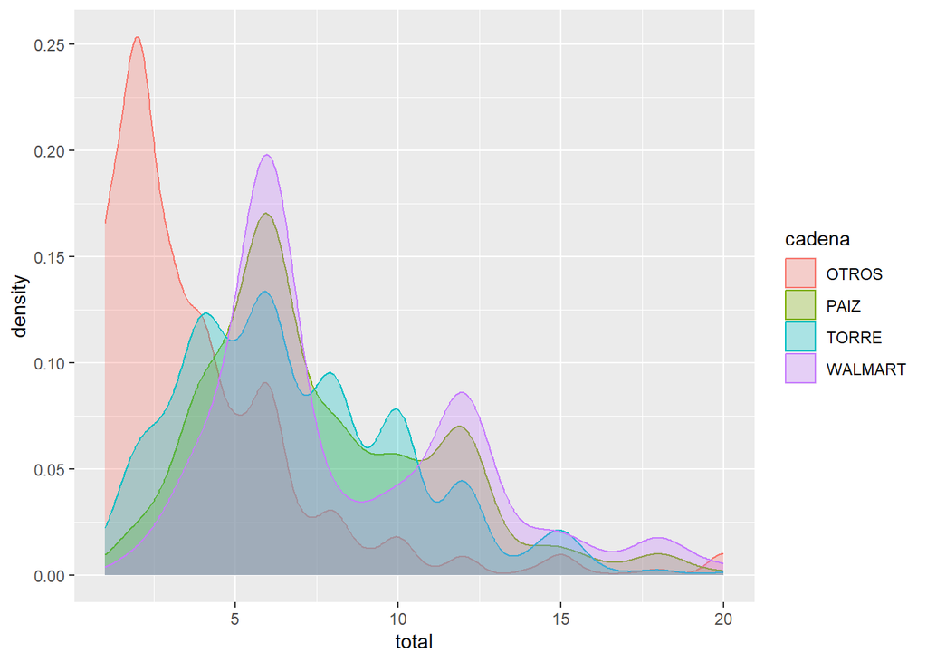

```r
data%>% filter(tipoEvento=="VENTAS",total<=20)%>% ggplot(aes(total, fill=cadena, col=cadena))+
  geom_density(alpha=0.3)
```

```r
summary(data$total)
```

```
##    Min. 1st Qu.  Median    Mean 3rd Qu.    Max.
##   1.000   3.000   5.000   5.912   8.000 226.000
```

Distribución promedio por venta en general

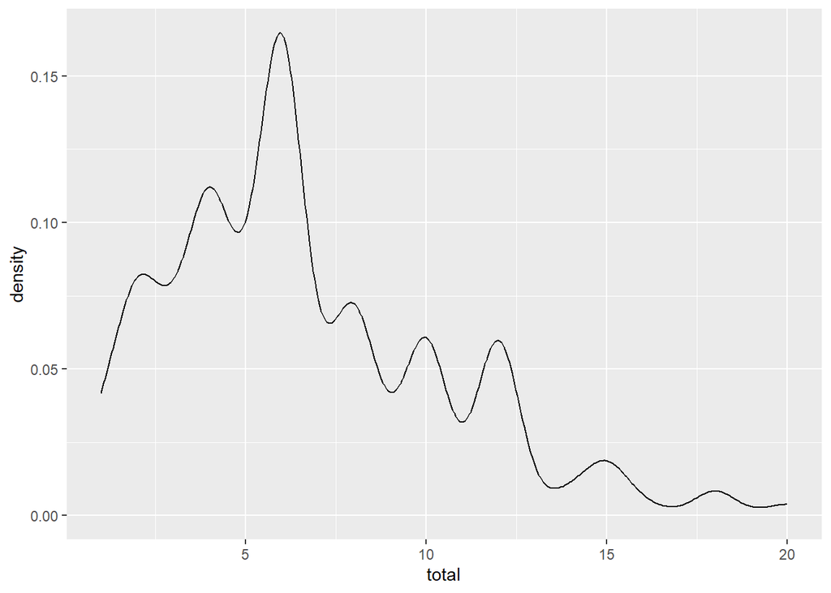

```r
data%>% filter(tipoEvento=="VENTAS",total<=20)%>% ggplot(aes(total))+
  geom_density(alpha=0.3)
```

Podemos observar que la relación entre cambios y ventas es alta, sin embargo, si vemos el gráfico de tendencia histórica, esto es un comportamiento que se dió a inicios de año y se ha ido reduciendo con el tiempo. Podría deberse a algún cambio de políticas o control de calidad de los productos, ya que la tendencia de ventas se mantiene igual.

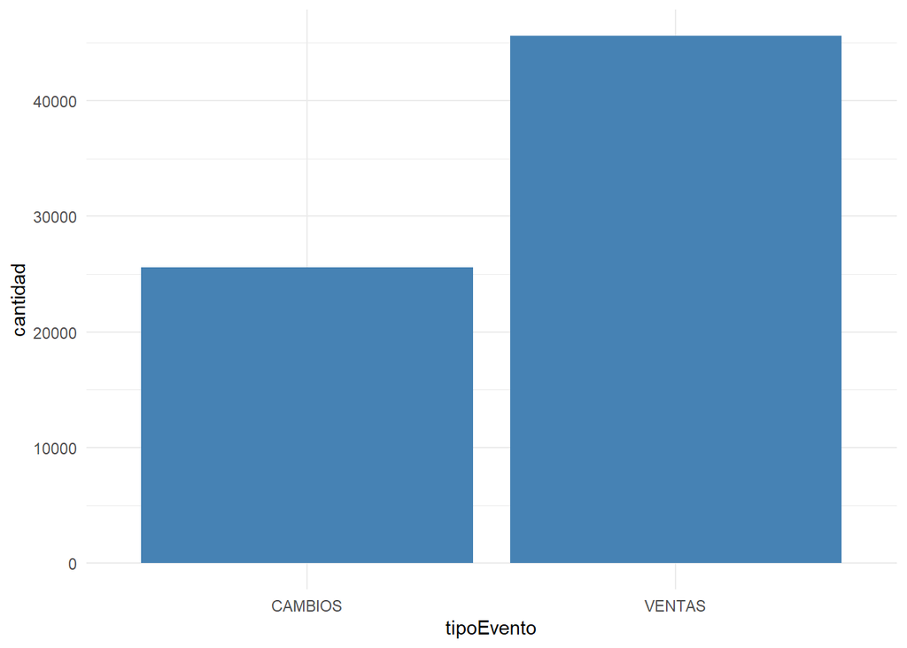

```r
data %>%
  group_by(tipoEvento) %>%
  summarise(cantidad = sum(total)) %>%
  ggplot(aes(x = tipoEvento, y = cantidad)) +
  geom_bar(stat = "identity", fill = "steelblue") +
  theme_minimal()
```

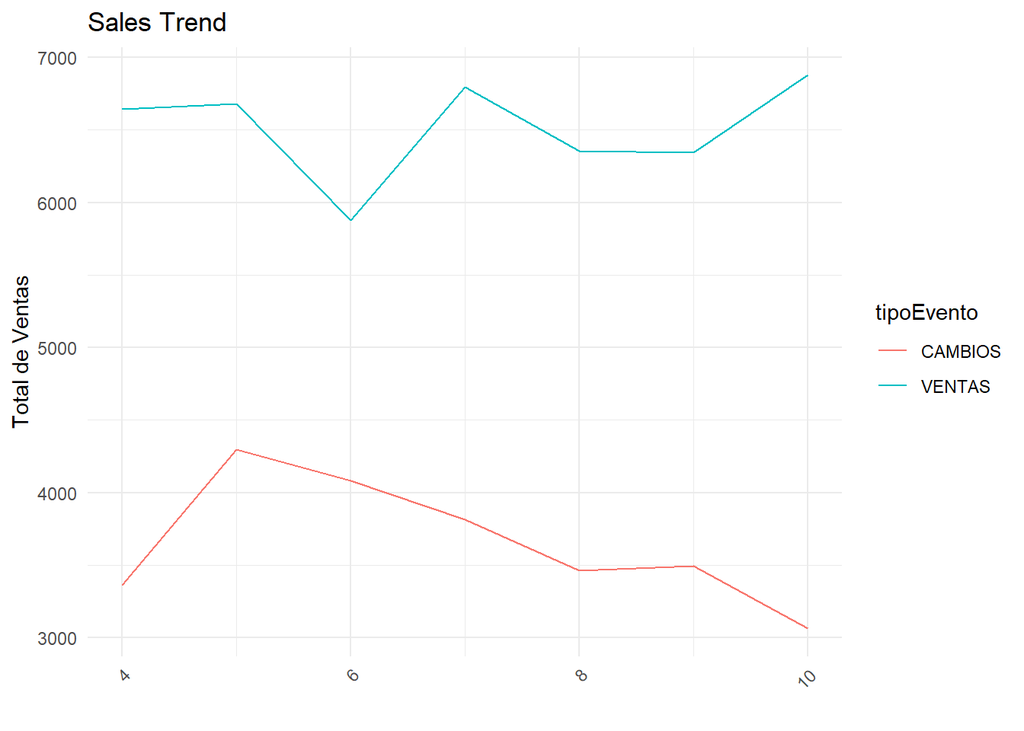

```r
# Análisis de Tendencias de Ventas a lo largo del tiempo

data %>% mutate(mes=month(factDate)) %>%
 group_by(tipoEvento, mes) %>% summarise(total=sum(total)) %>%
ggplot(aes(x = mes, y = total, color=tipoEvento)) +
  geom_line() +
  labs(title = "Sales Trend",
    y = "Total de Ventas",
    x="") +
  theme_minimal() +   theme(axis.text.x = element_text(angle = 45, hjust = 1))
```

## 3. Preparación de los datos

En esta etapa nos enfrentamos a la necesidad de organizar y estructurar nuestra información de manera que sea adecuada para la implementación de dos enfoques distintos. Dado que nuestra investigación se enfocará en la construcción de modelos de series de tiempo para analizar tendencias y patrones a lo largo del tiempo, así como en la segmentación de datos para identificar grupos y características específicas, hemos decidido crear dos data frames separados

### 3.1 Serie de tiempo

```r
# Filtrar las observaciones de ventas
ventas_df <- data %>%
  filter(tipoEvento == "VENTAS") %>%
  group_by(factDate) %>%
  summarise(ventas = sum(total))

# Filtrar las observaciones de cambios
cambios_df <- data %>%
  filter(tipoEvento == "CAMBIOS") %>%
  group_by(factDate) %>%
  summarise(cambios = sum(total))

# Creamos un data Frame con ambas columnas
serie_tiempo_df <- full_join(ventas_df, cambios_df, by = "factDate")

# Generamos un vector de fechas tipo POSIX para completar los días que no existen en el dataframe original
fecha_inicio <- as.Date("2023-04-01")
fecha_fin <- as.Date("2023-10-31")
factDate <- seq(from = as.POSIXct(fecha_inicio), to = as.POSIXct(fecha_fin), by = "days")
factDate <- as.Date(factDate)
fechas <- data.frame(factDate)

# Cruzamos la información contra los data frames previamente creado sustituyendo valores faltantes con 0, que se asumen como días con 0 ventas.
totalesDiarios <- fechas |> left_join(serie_tiempo_df, by="factDate") |>
  mutate(ventas=ifelse(is.na(ventas), 0, ventas), cambios=ifelse(is.na(cambios), 0, cambios))

#Generamos ambas series de tiempo para hacer pronósticos

ventasts <- ts(totalesDiarios$ventas, start =  as.Date("2023-04-01"), frequency = 7)
```

**Serie de tiempo de ventas**

```r
ventasts
```

```
## Time Series:
## Start = c(19448, 1)
## End = c(19478, 4)
## Frequency = 7
##   [1] 272   0 396 364 397   0   0   0   0 171 234 266 333 305 299   0 244 386
##  [19] 277 263 351 361   0 294 291 301 451 188 199   0   0 325 283 366 269 286
##  [37]   0 305 252 197 307 222 276   0 253 277 260 322 261 188   0 271 192 230
##  [55] 137 260 256   0 255 222 208 172 215 222   0 252 300 198 207 273 342   0
##  [73] 282 175 211 134 229 179   0 220 233 192 189 197 207   0 317 254 193 158
##  [91] 329 266   0   0 269 289 343 268 268 243 304 303 225 297 362 243   0 213
## [109] 208 241 249 254 244   0 253 286 223 155 270 273   0 248 249 233 191 270
## [127] 323   0 267 295   0 213 338 250   0 189   0 200 215 329 262   0 238 321
## [145] 264 184 268 236   0 244 289 267 221 273 283   0 242 320 247 284 235 253
## [163]   0 288 255 218 269   0 344   0 156 333 240 212 313 228   0 249 204 251
## [181] 183 220 244   0 215 224 349 207 379 189   0   0 385 357 362 361 439   0
## [199] 316 422 352 377   0 207   0 195 148 189 195 277 253   0 196 286
```

### 3.2 Clustering

En la fase de transformación de datos para el clustering, filtramos las observaciones de ventas para cada combinación de cadena y punto de venta. El enfoque principal es el modelo RFM (Recency, Frequency, Monetary), que descompone los datos en tres partes clave: cuándo ocurrieron las transacciones, con qué frecuencia suceden y cuánto valor tienen.

Luego, tomamos esos datos para cada punto de venta y los clasificamos en deciles. Esto significa dividir los datos en diez partes iguales, lo que nos ayuda a entender mejor cómo se distribuyen y varían los valores. Esta clasificación en deciles es esencial para nuestro siguiente paso: el análisis de clustering, donde agruparemos puntos de venta con características similares en términos de recencia, frecuencia y valor monetario.

En resumen, estamos utilizando el modelo RFM y clasificando en deciles para preparar nuestros datos antes de agrupar puntos de venta con comportamientos similares. Este proceso nos dará una visión más clara de los patrones en nuestros datos de ventas.

```r
# Frecuencia de ventas por cadena, punto de venta y fecha
frequency <- data %>%
  filter(tipoEvento == "VENTAS") %>%
  group_by(cadena, puntoDeVenta, factDate) %>%
  summarise(count = n()) %>%
  group_by(cadena, puntoDeVenta) %>%
  summarise(frequency = sum(count))

# Última fecha de compra por cadena y punto de venta
lastPurchase <- data %>%
  filter(tipoEvento == "VENTAS") %>%
  group_by(cadena, puntoDeVenta) %>%
  summarise(lastPurchase = max(factDate))

# Preparación de datos para el clustering
dataClusterPrev <- data %>%
  filter(tipoEvento == "VENTAS") %>%
  left_join(locations, by = c("cadena", "puntoDeVenta")) %>%
  mutate(productoReal = paste(producto, tipo, sep = "_")) %>%
  group_by(cadena, puntoDeVenta, productoReal, lat, long) %>%
  summarise(ventas = sum(total)) %>%
  pivot_wider(names_from = productoReal, values_from = ventas) %>%
  mutate_all(~replace(., is.na(.), 0)) %>%
  mutate(
    regular = REGULAR_B + REGULAR_I,
    chips = CHIPS_I + CHIPS_SP,
    tahini = TAHINI_TH,
    mini = MINI_B + MINI_I,
    porc_integral = ifelse(
      is.nan((CHIPS_I + MINI_I) / (CHIPS_I + CHIPS_SP + MINI_B + MINI_I + REGULAR_B + REGULAR_I)),
      0,
      (CHIPS_I + MINI_I) / (CHIPS_I + CHIPS_SP + MINI_B + MINI_I + REGULAR_B + REGULAR_I)
    ),
    monetary = CHIPS_I + CHIPS_SP + MINI_B + MINI_I + REGULAR_B + REGULAR_I + TAHINI_TH
  ) %>%
  left_join(frequency, by = c("cadena", "puntoDeVenta")) %>%
  left_join(lastPurchase, by = c("cadena", "puntoDeVenta")) %>%
  mutate(recency = as.numeric(difftime(as.POSIXct("2023-10-31 00:00:00"), lastPurchase, units = "days")))

# Cálculo de cuantiles para recencia, frecuencia y valor monetario
decilRecency <- quantile(dataClusterPrev$recency, probs = seq(0, 1, by = 0.1))
decilFrequency <- quantile(dataClusterPrev$frequency, probs = seq(0, 1, by = 0.1))
decilMonetary <- quantile(dataClusterPrev$monetary, probs = seq(0, 1, by = 0.1))

# Etiquetar los cuantiles en el marco de datos original
dataClusterPrev$decilRecency <- cut(dataClusterPrev$recency, breaks = decilRecency, labels = FALSE, include.lowest = TRUE)
dataClusterPrev$decilFrequency <- cut(dataClusterPrev$frequency, breaks = decilFrequency, labels = FALSE, include.lowest = TRUE)
dataClusterPrev$decilMonetary <- cut(dataClusterPrev$monetary, breaks = decilMonetary, labels = FALSE, include.lowest = TRUE)

# Mapeo de deciles para recencia
dataClusterPrev <- dataClusterPrev %>% mutate( decilRecency=ifelse(decilRecency == 10, 1,
                            ifelse(decilRecency == 9, 2,
                                   ifelse(decilRecency == 8, 3,
                                          ifelse(decilRecency == 7, 4,
                                                 ifelse(decilRecency == 6, 5,
                                                        ifelse(decilRecency == 5, 6,
                                                               ifelse(decilRecency == 4, 7,
                                                                      ifelse(decilRecency == 3, 8,
                                                                             ifelse(decilRecency == 2, 9,
                                                                                    ifelse(decilRecency == 1, 10, NA)))))))))))

# Seleccionar columnas relevantes para el clustering
dataCluster <- dataClusterPrev[, c("cadena", "puntoDeVenta", "regular", "chips", "tahini", "mini", "porc_integral", "decilRecency", "decilFrequency", "decilMonetary")]
```

**Dataset para clustering**

```r
# Mostrar las primeras filas del marco de datos resultante
head(dataCluster)
```

```
## # A tibble: 6 × 10
## # Groups:   cadena, puntoDeVenta [6]
##   cadena puntoDeVenta      regular chips tahini  mini porc_integral decilRecency
##   <chr>  <chr>               <dbl> <dbl>  <dbl> <dbl>         <dbl>        <dbl>
## 1 OTROS  ALLPITA              1360     0      0     0         0                4
## 2 OTROS  BODEGA DELICA (E…       0    58     21     0         0.483            3
## 3 OTROS  BODEGONA              173   201    233   313         0.336           10
## 4 OTROS  BOHRU                   0    24      2     0         1                8
## 5 OTROS  CLIENTE QUETZALT…      62     0      0     0         0                4
## 6 OTROS  CLIENTE ZONA 2          0     0      0    10         0                4
## # ℹ 2 more variables: decilFrequency <int>, decilMonetary <int>
```

## 4. Modelado de datos

### 4.1 Series de tiempo

**Descomposición de serie de tiempo de ventas**

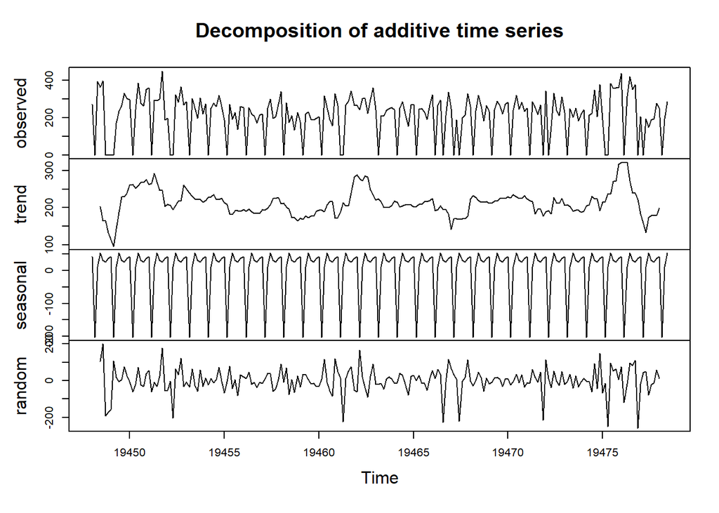

```r
# Descomponer la serie de tiempo ventas
descomposicion <- decompose(ventasts)

# Graficar la descomposición
par(mfrow = c(2, 2))
plot(descomposicion)
```

**Generando modelos**

Un modelo ARIMA (Autorregresivo de Media Móvil) es un enfoque estadístico utilizado en el análisis de series temporales para modelar la relación entre observaciones pasadas y presentes. La componente autorregresiva (AR) implica que las observaciones actuales dependen linealmente de las anteriores, mientras que la componente de media móvil (MA) indica que las observaciones actuales están relacionadas con los errores residuales pasados. Juntos, estos componentes permiten capturar patrones complejos y predecir valores futuros en una serie temporal.

```r
# Ajustar un modelo arima
ventasForecast <- forecast(auto.arima(ventasts), h = 14)  # Pronosticar los próximos 14 días

# Mostrar el pronóstico
print(ventasForecast)
```

```
##          Point Forecast      Lo 80    Hi 80      Lo 95    Hi 95
## 19478.57  305.549609345  188.48991 422.6093  126.52224 484.5770
## 19478.71  325.403190682  207.24024 443.5661  144.68856 506.1178
## 19478.86  193.902005756   75.71827 312.0857   13.15557 374.6484
## 19479.00  298.780266470  180.59613 416.9644  118.03323 479.5273
## 19479.14   -0.002709345 -118.18685 118.1814 -180.74976 180.7443
## 19479.29  237.147490758  118.96335 355.3316   56.40044 417.8945
## 19479.43  277.274061934  159.08992 395.4582   96.52702 458.0211
## 19479.57  274.491714207  152.75926 396.2242   88.31799 460.6654
## 19479.71  290.523822467  168.72517 412.3225  104.24885 476.7988
## 19479.86  160.371306220   38.57140 282.1712  -25.90558 346.6482
## 19480.00  248.482251542  126.68232 370.2822   62.20533 434.7592
## 19480.14   -0.000675302 -121.80061 121.7993 -186.27760 186.2762
## 19480.29  205.909670054   84.10974 327.7096   19.63275 392.1866
## 19480.43  236.039877613  114.23994 357.8398   49.76295 422.3168
```

**Forecast de ventas** Visualizando el forecast de ventas

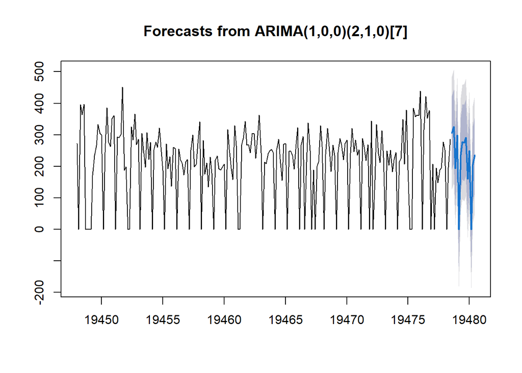

```r
plot(ventasForecast)
```

### 4.1 Clustering

```r
# Seleccionar las columnas relevantes para el clustering
dataModelo <- dataCluster[, 7:ncol(dataCluster)]


# Realizar clustering con k-means (por ejemplo, con k=3)
kmeansModel <- kmeans(dataModelo, centers = 3)

# Asignar las etiquetas de cluster a los datos
clusterLabels <- as.factor(kmeansModel$cluster)
dataClusterPrev$cluster <- clusterLabels
```

## 5. Evaluación

### 5.1 Series de tiempo

A pesar de que los residuos de nuestro modelo ARIMA(1,0,0)(2,1,0)[7] no exhiben una distribución completamente normal, hemos decidido utilizarlos en nuestro análisis. Esto se debe a las limitaciones en la cantidad de muestras disponibles. El resultado del Ljung-Box test (Q* = 23.088, df = 11, p-value = 0.01717) indica cierta autocorrelación en los residuos, lo cual podría sugerir falta de ajuste del modelo. Sin embargo, dada la naturaleza de nuestras pocas observaciones (Model df: 3, Total lags used: 14), consideramos que estos residuos representan el mejor estimado posible para nuestro modelo ARIMA en estas condiciones. Aunque la normalidad no es perfecta, creemos que los resultados son suficientemente sólidos para respaldar nuestras conclusiones

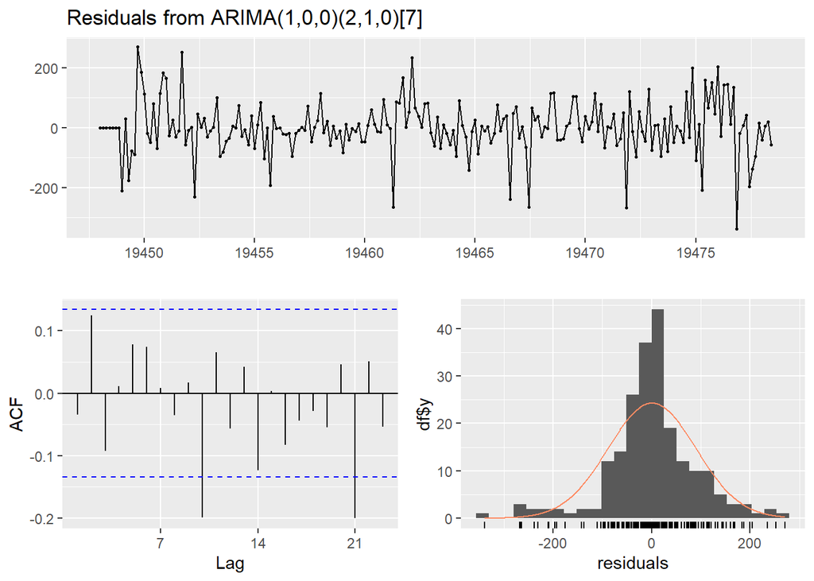

```
##
##  Ljung-Box test
##
## data:  Residuals from ARIMA(1,0,0)(2,1,0)[7]
## Q* = 23.088, df = 11, p-value = 0.01717
##
## Model df: 3.   Total lags used: 14
```

```r
checkresiduals(ventasForecast)
```

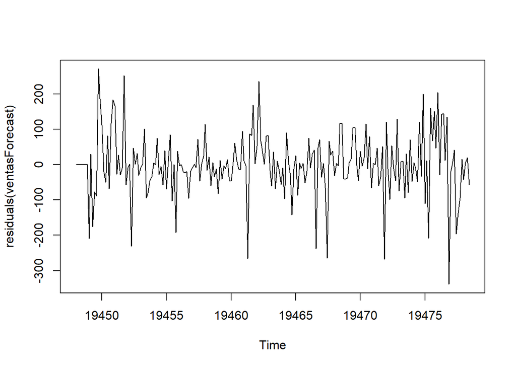

```r
# Visualizar residuos
plot(residuals(ventasForecast))
```

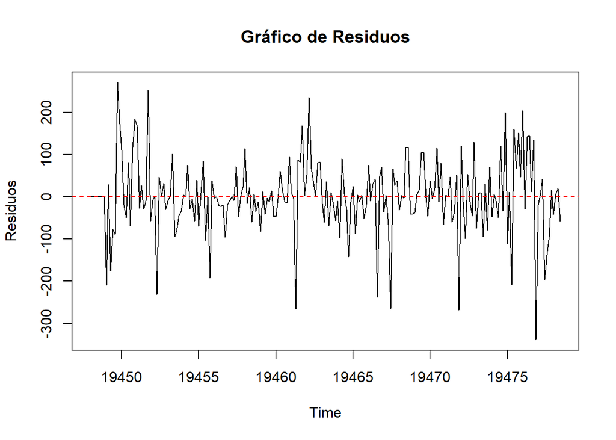

```r
# Supongamos que ya has ajustado tu modelo ARIMA y lo has almacenado en una variable llamada arima_model

# Visualizar los residuos
plot(residuals(ventasForecast), main = "Gráfico de Residuos", ylab = "Residuos")

# Puedes agregar líneas horizontales en 0 para ayudar a identificar patrones
abline(h = 0, col = "red", lty = 2)
```

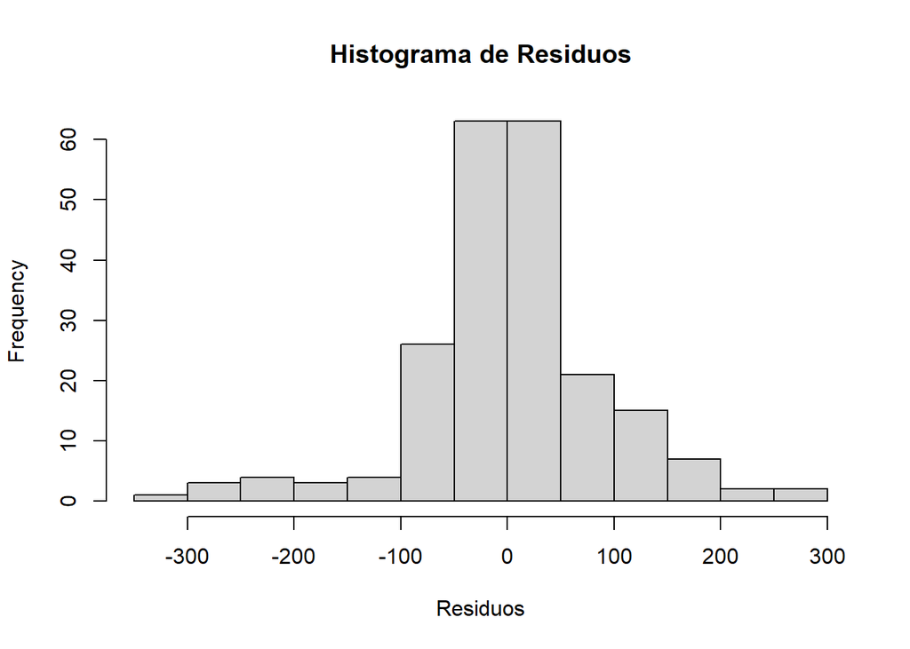

```r
hist(residuals(ventasForecast), main = "Histograma de Residuos", xlab = "Residuos")
```

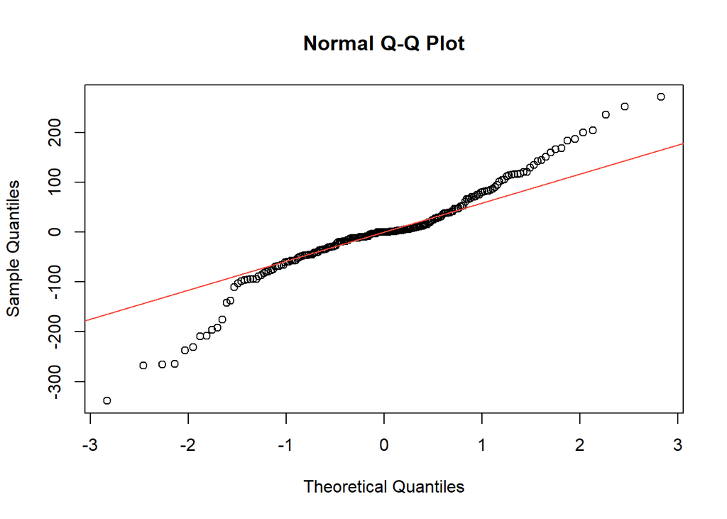

```r
qqnorm(residuals(ventasForecast))
qqline(residuals(ventasForecast), col = 2)
```

```r
shapiro.test(residuals(ventasForecast))
```

```
##
##  Shapiro-Wilk normality test
##
## data:  residuals(ventasForecast)
## W = 0.94436, p-value = 2.556e-07
```

### 5.2 Clustering

```r
#Resultado de los cluster

dataClusterPrev %>% group_by(cluster) %>% summarise(recency=mean(recency), frequency=mean(frequency), monetary=mean(monetary), porcIntegral=mean(porc_integral), count=n())
```

```
## # A tibble: 3 × 6
##   cluster recency frequency monetary porcIntegral count
##   <fct>     <dbl>     <dbl>    <dbl>        <dbl> <int>
## 1 1          4.47     105.     795.         0.431    50
## 2 2          3.04      25       98.4        0.491    14
## 3 3         84.5       16.6     91.4        0.418    49
```

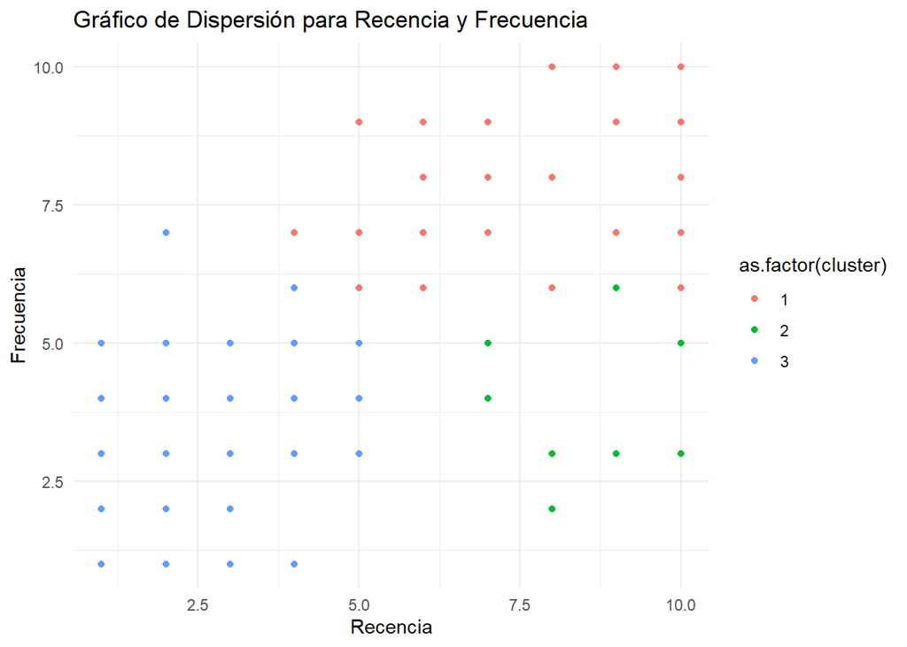

```r
dataClusterPrev$recency <- as.numeric(dataClusterPrev$recency)
dataClusterPrev$frequency <- as.numeric(dataClusterPrev$frequency)
dataClusterPrev$monetary <- as.numeric(dataClusterPrev$monetary)

# Gráfico de dispersión para recencia y frecuencia
ggplot(dataClusterPrev, aes(x = decilRecency, y = decilFrequency, color = as.factor(cluster))) +
  geom_point() +
  labs(title = "Gráfico de Dispersión para Recencia y Frecuencia",
       x = "Recencia",
       y = "Frecuencia") +
  theme_minimal()
```

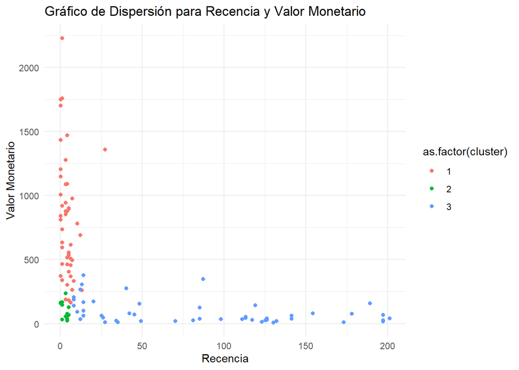

```r
# Gráfico de dispersión para recencia y valor monetario
ggplot(dataClusterPrev, aes(x = recency, y = monetary, color = as.factor(cluster))) +
  geom_point() +
  labs(title = "Gráfico de Dispersión para Recencia y Valor Monetario",
       x = "Recencia",
       y = "Valor Monetario") +
  theme_minimal()
```

**Método de la silueta:**

El método de la silueta ha sido aplicado a nuestros datos de clustering, proporcionando una visión de la coherencia y separación de los grupos identificados

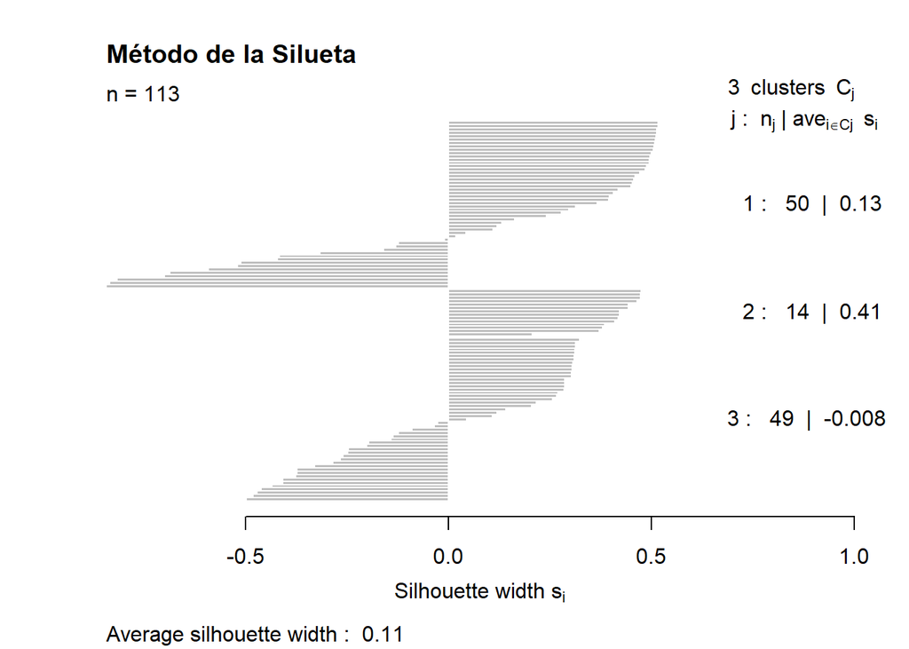

```r
silhouette <- silhouette(as.numeric(as.character(dataClusterPrev$cluster)),
                         dist(dataClusterPrev[, c("recency", "frequency", "monetary")]))
plot(silhouette, main = "Método de la Silueta")
```

## 6. Despliegue

La fase de despliegue es la parte en donde la empresa debe de convertir los resultados del análisis en acciones concretas y efectivas para el negocio. Debido al escaso tiempo de este trabajo se describirá esta etapa como una recomendación que se brinda a la empresa Davids para el despliegue de esta evaluación. Con esto se espera que Davids implemente y ponga en práctica las soluciones desarrolladas a lo largo del proyecto. Aquí se detallarán los pasos clave a seguir.

### 6.1 Implementación de modelos de Series Temporales

- Integración: Debemos encontrar la manera en cómo se integrará el modelo ARIMA en el sistema de información existente. Puede ser necesario desarrollar interfaces o conexiones para que el modelo pueda recibir datos en tiempo real.
- Automatización: Importante establecer un proceso de automatización para la actualización periódica del modelo. Las series de tiempo evolucionan, y es fundamental que el modelo se ajuste continuamente a los nuevos datos.
- Monitoreo Continuo: Es necesaria la implementación de un sistema de monitoreo continuo para evaluar el rendimiento del modelo en producción. Esto implica el seguimiento de métricas de error, la identificación de posibles desviaciones y la recalibración del modelo según sea necesario.
- Documentación: Es clave documentar adecuadamente la implementación, incluyendo los parámetros del modelo, las fuentes de datos, y cualquier consideración importante. Esto facilitará futuras actualizaciones y la comprensión por parte de otros miembros del equipo.

### 6.2 Despliegue del modelo de Clustering

Para el modelo de clustering basado en K-Means, la implementación y despliegue involucran los siguientes pasos: * Estrategias Comerciales: Como primer paso es importante comunicar los resultados del clustering a los equipos responsables de estrategias comerciales. Con esta información deben desarrollar planes específicos para abordar cada segmento identificado, como programas de lealtad, estrategias de retención y campañas promocionales adaptadas a las características de cada cluster.

- Capacitación: El aprendizaje continuo es clave para la cultura de la organización y en este caso no es la excepción, se debe proveer capacitación al personal que interactuará con los resultados del clustering. Esto garantizará una comprensión adecuada de cómo utilizar la información para mejorar las relaciones con los clientes y optimizar las estrategias comerciales.
- Marketing: Asegúrate de que los resultados del clustering se integren con sistemas de marketing digital, herramientas de segmentación de clientes como lo puede ser el CRM. Esto permitirá una implementación efectiva de campañas específicas para cada grupo.
- Medición del Impacto: Si no lo medimos no podemos mejorar, por lo que se deben establecer indicadores clave de rendimiento (KPIs) para medir el impacto de las estrategias implementadas basadas en el clustering. Monitorear continuamente estos KPIs para ajustar las estrategias según sea necesario.

### 6.3 Despliegue del modelo de Clustering

Ya que el despliegue no marca el final del proceso, recomendamos iniciar con reuniones mensuales para dar comienzo a una fase de evaluación continua y poder continuar brindando un asesoramiento. A medida que las soluciones se implementan y se integran en las operaciones comerciales, es esencial evaluar su impacto y realizar ajustes según sea necesario. La retroalimentación continua del usuario, el monitoreo de métricas clave y la adaptación a cambios en el entorno son prácticas importantes para garantizar que las soluciones sigan siendo efectivas y relevantes para Davids a lo largo del tiempo.